# Analyse de Sensibilité et Métamodélisation : Modèle Borehole

ALOUI Ghaieth

27 Février 2026

## 0) Introduction et Fonctions du Modèle

Ce document présente l’étude du modèle de forage `borehole`, évaluant le débit d’eau en fonction de 13 variables d’entrée incertaines.

Le débit d’eau $y$ (en $m^3/an$) traversant le forage est modélisé par l’équation analytique suivante :

$$y = \frac{2 \pi T_u (H_u -
H_l)}{\ln\left(\frac{r}{r_w}\right) \left[ 1 + \frac{2 L
T_u}{\ln\left(\frac{r}{r_w}\right) r_w^2 K_w} + \frac{T_u}{T_l}
\right]}$$

Avec les variables physiques définies ainsi :

- $r_w$ : Rayon du forage (m)
- $r$ : Rayon d’influence (m)
- $T_u$ : Transmissivité de l’aquifère supérieur ($m^2/an$)
- $H_u$ : Hauteur potentiométrique de l’aquifère supérieur (m)
- $T_l$ : Transmissivité de l’aquifère inférieur ($m^2/an$)
- $H_l$ : Hauteur potentiométrique de l’aquifère inférieur (m)
- $L$ : Longueur du forage (m)
- $K_w$ : Conductivité hydraulique du forage ($m/an$)

```r
# Fonction du modèle physique
borehole <- function(x) {
  xx <- matrix(x, ncol=13)
  rw  <- xx[,1];
  riw <- xx[,2];
  r   <- xx[,3]
  Tu  <- xx[,4];
  Hu  <- xx[,5];
  Tum <- xx[,6]
  Hum <- xx[,7];
  Tlm <- xx[,8];
  Hlm <- xx[,9]
  Tl  <- xx[,10];
  Hl  <- xx[,11];
  L   <- xx[,12];
  Kw  <- xx[,13];

  frac1 <- 2 * pi * Tu * (Hu-Hl)
  frac11 <- (Tum - Tlm) * (Hum - Hlm)
  frac2 <- frac1 / frac11

  frac2a <- 2*L*Tu / (log(r/rw)*rw^2*Kw)
  frac2b <- Tu / Tl
  frac2 <- log(r/rw) * (1+frac2a+frac2b)

  y <- frac1 / frac2
  return(y)
}

# Fonction d'échantillonnage
EchantBorehole <- function(N){
  X = matrix(NA, N, 13)
  X[,1] <- rnorm(N, 0.1, 0.015)
  X[,2] <- rnorm(N, 0.05, 0.01)
  X[,3] <- rlnorm(N, 7.71, 1.0056)
  X[,4] <- runif(N, 63100, 116000)
  X[,5] <- runif(N, 1000, 1100)
  X[,6] <- runif(N, 6310, 11600)
  X[,7] <- runif(N, 900, 1000)
  X[,8] <- runif(N, 631, 1160)
  X[,9] <- runif(N, 800, 900)
  X[,10] <- runif(N, 63.1, 116)
  X[,11] <- runif(N, 700, 800)
  X[,12] <- runif(N, 1120, 1680)
  X[,13] <- runif(N, 3000, 12000)
  colnames(X) <- c("rw","riw","r","Tu","Hu","Tum","Hum","Tlm","Hlm","Tl","Hl","L","Kw")
  return(X)
}
```

> **Remarque importante :** Il est à noter que dans le script R fourni, la variable `frac2` est d’abord calculée puis immédiatement écrasée par la modélisation de la résistance hydraulique du forage. Par conséquent, les variables relatives à l’aquifère moyen ($T_{um}$, $T_{lm}$, $H_{um}$, $H_{lm}$) sont rendues **inactives** et n’ont aucun impact sur le résultat final.

> L’exactitude de cette implémentation analytique (sans l’aquifère moyen) est par ailleurs confirmée par la référence sur les modèles de simulation : [Virtual Library of Simulation Experiments - Borehole Function](https://www.sfu.ca/~ssurjano/borehole.html).

> *Tout le reste de l’analyse présentée dans ce document sera basé sur le modèle tel que décrit et implémenté dans la fonction `borehole()` fournie pour ce TP.*

## 1) Mise en place

Pour cette première étape d’appropriation, nous évaluons la fonction aux bornes de son domaine de définition ainsi qu’à son point central. La variable aléatoire du rayon d’influence $r$ suit une loi lognormale. L’espérance mathématique se calcule via la formule :
$$\mathbb{E}(r) = \exp(\mu + \frac{\sigma^2}{2})$$
Avec $\mu=7.71$ et $\sigma=1.0056$, nous obtenons environ $3698.24 m$.

```r
x_min <- c(0.05, 0.02, 100, 63100, 1000, 6310, 900, 631, 800, 63.1, 700, 1120, 3000)
x_max <- c(0.15, 0.08, 50000, 116000, 1100, 11600, 1000, 1160, 900, 116, 800, 1680, 12000)

mu_r <- 7.71; sigma_r <- 1.0056
mean_r <- exp(mu_r + (sigma_r^2) / 2)

x_mean <- c(0.10, 0.05, mean_r,
            mean(c(63100, 116000)), mean(c(1000, 1100)), mean(c(6310, 11600)),
            mean(c(900, 1000)), mean(c(631, 1160)), mean(c(800, 900)),
            mean(c(63.1, 116)), mean(c(700, 800)), mean(c(1120, 1680)),
            mean(c(3000, 12000)))

resultats <- data.frame(
  Configuration = c("Valeurs Minimales", "Valeurs Moyennes", "Valeurs Maximales"),
  Debit_eau = c(borehole(x_min), borehole(x_mean), borehole(x_max))
)
knitr::kable(resultats, digits = 2, caption = "Réponse du modèle aux points caractéristiques")
```

Réponse du modèle aux points caractéristiques

| Configuration | Debit_eau |
| --- | --- |
| Valeurs Minimales | 6.31 |
| Valeurs Moyennes | 50.33 |
| Valeurs Maximales | 150.15 |

## 2) Propagation d’incertitudes par Monte Carlo

### 2-a)

On effectue $1000$ echantillon Monte Carlo et on calcule la moyenne et la variance de la sortie

```r
N <- 1000
X_mc <- EchantBorehole(N)
y_mc <- borehole(X_mc)

cat("Moyenne empirique :", round(mean(y_mc), 2), "m3/an\n")
```

```
## Moyenne empirique : 51.59 m3/an
```

```r
cat("Variance empirique :", round(var(y_mc), 2), "(m3/an)^2\n")
```

```
## Variance empirique : 703.19 (m3/an)^2
```

Nous visualisons les Résultats dans un histogramme

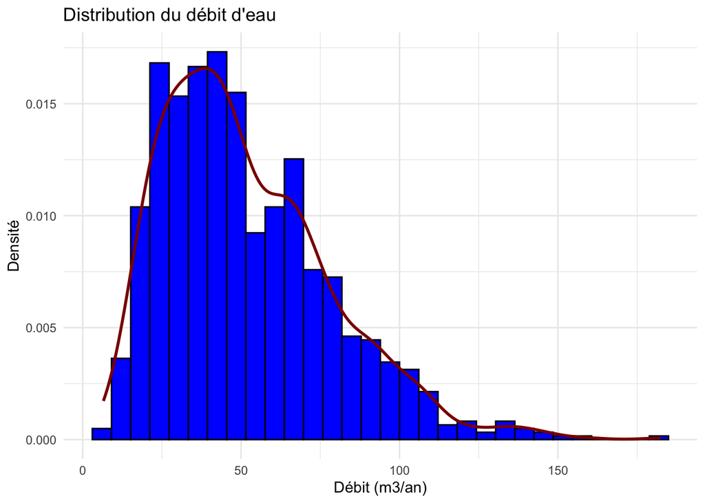

```r
df_y <- data.frame(Debit = y_mc)
ggplot(df_y, aes(x = Debit)) +
  geom_histogram(aes(y = after_stat(density)), bins = 30, fill = "blue", color = "black") +
  geom_density(color = "darkred", linewidth = 1) +
  labs(title = "Distribution du débit d'eau", x = "Débit (m3/an)", y = "Densité") +
  theme_minimal()
```

### 2-b)

Nous allons comparer la moyenne empirique par échantillons Monte Carlo et la réponse du modèle en les valeurs moyennes des variables.

```r
print(borehole(x_mean))
```

```
## [1] 50.33137
```

```r
print((mean(y_mc)))
```

```
## [1] 51.58994
```

On remarque que la moyenne de la réponse est supérieure à la réponse de la moyenne, ce qui est confirmé par l’inégalité de Jensen qui nous indique pour une variable aléatoire $X$ et une fonction bornée $f$ :

$$\mathbb{E}(f(X)) \geq f(\mathbb{E}(X))$$

Puisque qu’on a pas une égalité entre les deux quantité cela demontre la *non-linéarité* du modèle. (linéarité = Cas d’égalité de l’inégalité de Jensen)

### 2-c) Calcul du quantile à 95% et intervalle de confiance (Bootstrap)

À partir de notre échantillon de Monte Carlo initial (de taille $N = 1000$), nous calculons d’abord le quantile d’ordre 95% empirique. Ensuite, pour estimer l’intervalle de confiance à 95% de ce quantile, nous utilisons la méthode du rééchantillonnage (**Bootstrap**) : nous tirons notre sortie avec remise un grand nombre de fois ($B = 10000$) pour construire une distribution empirique de ce quantile, puis nous en extrayons les bornes à 2.5% et 97.5%.

```r
# 1. Calcul du quantile à 95% sur l'échantillon initial
q95 <- quantile(y_mc, probs = 0.95)

# 2. Estimation de l'intervalle de confiance par Bootstrap
set.seed(42)
B <- 10000   # Nombre de répétitions

# Création d'un vecteur pour stocker les quantiles bootstrappés
boot_quantiles <- replicate(B, {
  echantillon_boot <- sample(y_mc, size = length(y_mc), replace = TRUE)
  quantile(echantillon_boot, probs = 0.95)
})

# Calcul des quantiles à 2.5% et 97.5% de la distribution obtenue
ic_95 <- quantile(boot_quantiles, probs = c(0.025, 0.975))

# Affichage clair des résultats
cat("Le quantile d'ordre 95% estimé est :", round(q95, 2), "m3/an\n")
```

```
## Le quantile d'ordre 95% estimé est : 102.09 m3/an
```

```r
cat("L'intervalle de confiance à 95% de ce quantile est : [",
    round(ic_95[1], 2), ";", round(ic_95[2], 2), "] m3/an\n")
```

```
## L'intervalle de confiance à 95% de ce quantile est : [ 96.3 ; 105.66 ] m3/an
```

**Interprétation et détails de la méthode :**

1. **Signification du quantile à 95% :** Dans le contexte de notre modèle, le quantile à 95% représente une valeur seuil de débit d’eau. Concrètement, cela signifie que selon notre modèle et les incertitudes de nos variables d’entrée, il y a 95% de chances que le débit du forage soit inférieur ou égal à cette valeur (et inversement, seulement 5% de chances qu’il la dépasse). C’est un indicateur crucial pour l’évaluation des risques extrêmes.
2. **Principe du rééchantillonnage Bootstrap :** L’estimation de ce quantile (calculée sur notre unique échantillon Monte Carlo de taille $N = 1000$) est soumise à une incertitude statistique. Pour quantifier cette incertitude sans avoir à relancer le modèle physique `borehole()` des milliers de fois (ce qui serait très coûteux en temps de calcul dans un cas réel), nous utilisons la méthode du **Bootstrap non-paramétrique**.
3. **La démarche algorithmique étape par étape :**
   - **Tirage avec remise :** À partir de notre échantillon initial de 1000 débits, nous “piochons” aléatoirement 1000 valeurs *avec remise*. Certaines valeurs de l’échantillon initial seront sélectionnées plusieurs fois, d’autres ignorées. Cela crée un “nouvel” échantillon virtuel.
   - **Calcul itératif :** Sur ce nouvel échantillon, nous recalculons le quantile à 95%.
   - **Répétition :** Nous répétons cette opération un grand nombre de fois ($B = 10000$ fois) pour obtenir non plus une seule estimation du quantile, mais une véritable *distribution statistique* de ce quantile.
   - **Extraction de l’intervalle :** Enfin, nous trions ces 10000 valeurs de quantiles simulés et nous prenons les valeurs situées à 2.5% (borne inférieure) et 97.5% (borne supérieure). L’écart entre ces deux bornes nous donne notre intervalle de confiance à 95%, garantissant la robustesse de notre estimation initiale.

### 2-d) Calcul de la probabilité de dépassement de seuil par Monte Carlo

L’objectif est d’estimer la probabilité $p = \mathbb{P}(y > 250 \text{ m}^3/\text{an})$ à l’aide de la méthode de Monte Carlo. L’estimateur empirique de cette probabilité est donné par la moyenne de la fonction indicatrice :
$$\hat{p} = \frac{1}{N} \sum_{i=1}^{N} \mathbf{1}_{\{y_i > 250\}}$$

Pour s’assurer de la précision de notre estimation, nous fixons une condition d’arrêt basée sur l’**erreur relative** (définie par le coefficient de variation de l’estimateur). Celle-ci doit être inférieure ou égale à 10% (0.10). La formule de l’erreur relative $\epsilon_{rel}$ est :
$$\epsilon_{rel} = \frac{\sqrt{\text{Var}(\hat{p})}}{\hat{p}} =
\frac{\sqrt{\frac{\hat{p}(1-\hat{p})}{N}}}{\hat{p}} =
\sqrt{\frac{1-\hat{p}}{N \cdot \hat{p}}} \leq 0.10$$

Pour optimiser la gestion de la mémoire sous R (éviter de manipuler des matrices géantes d’un seul coup), nous adoptons une approche itérative “par lots” : nous générons des échantillons par paquets de $2 \cdot 10^6$, et nous mettons à jour notre probabilité globale jusqu’à atteindre le critère de convergence.

```r
# Initialisation des paramètres de la boucle
N_total <- 0
succes_total <- 0
erreur_relative <- 1
pas_N <- 2e6         # Pas d'incrément

# Vecteurs pour stocker l'historique et tracer la convergence
valeurs_N <- c()
valeurs_p <- c()
valeurs_err <- c()

set.seed(123)

# Boucle d'incrémentation jusqu'à obtenir une erreur relative <= 10%
while(erreur_relative > 0.10) {

  # 1. Génération d'un nouveau lot de données
  X_batch <- EchantBorehole(pas_N)
  y_batch <- borehole(X_batch)

  # 2. Mise à jour des compteurs globaux
  succes_total <- succes_total + sum(y_batch > 250)
  N_total <- N_total + pas_N

  # 3. Calcul de la nouvelle probabilité estimée
  p_est <- succes_total / N_total

  # 4. Évaluation de l'erreur relative
  if(p_est > 0) {
    erreur_relative <- sqrt((p_est * (1 - p_est)) / N_total) / p_est
  } else {
    erreur_relative <- 1 # Sécurité mathématique si p_est = 0
  }

  # 5. Stockage pour le graphique de convergence
  valeurs_N <- c(valeurs_N, N_total)
  valeurs_p <- c(valeurs_p, p_est)
  valeurs_err <- c(valeurs_err, erreur_relative)
}

#Affichage des résultats finaux
cat("Taille d'échantillon totale nécessaire :", format(N_total, scientific = TRUE), "simulations\n")
```

```
## Taille d'échantillon totale nécessaire : 3.6e+07 simulations
```

```r
cat("Probabilité estimée P(y > 250)         :", p_est,"\n")
```

```
## Probabilité estimée P(y > 250)         : 2.888889e-06
```

```r
cat("Erreur relative finale atteinte        :", round(erreur_relative * 100, 2), "%\n")
```

```
## Erreur relative finale atteinte        : 9.81 %
```

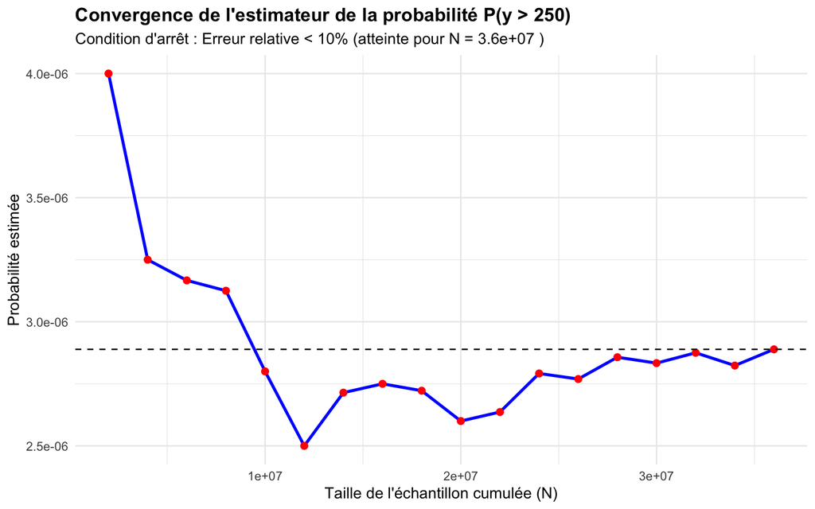

```r
#Création du graphique de convergence avec ggplot2
library(ggplot2)
df_conv <- data.frame(N = valeurs_N, Probabilite = valeurs_p)

ggplot(df_conv, aes(x = N, y = Probabilite)) +
  geom_line(color = "blue", linewidth = 1) +
  geom_point(color = "red", size = 2) +
  geom_hline(yintercept = p_est, linetype = "dashed", color = "black") +
  scale_x_continuous(labels = scales::scientific) +
  labs(title = "Convergence de l'estimateur de la probabilité P(y > 250)",
       subtitle = paste("Condition d'arrêt : Erreur relative < 10% (atteinte pour N =", format(N_total, scientific = TRUE), ")"),
       x = "Taille de l'échantillon cumulée (N)",
       y = "Probabilité estimée") +
  theme_minimal() +
  theme(plot.title = element_text(face = "bold"))
```

**Interprétation du graphique de convergence :**

Le graphique confirme que l’événement étudié (un débit supérieur à 250 m3/an) est extrêmement rare, avec une probabilité asymptotique de l’ordre de **2.88e-06**. Dans le cadre de la méthode de Monte Carlo, pour garantir une erreur relative de **10%**, il est nécessaire d’observer une centaine d’événements positifs. Mathématiquement, cela exige un nombre d’itérations $N \approx \frac{100}{p}$. Notre algorithme itératif valide cette théorie mathématique en atteignant le critère d’arrêt à $N = 3.6 \times 10^7$ simulations. La courbe illustre parfaitement la réduction de la variance de l’estimateur : après de fortes oscillations initiales dues à la rareté de l’événement, la probabilité empirique se stabilise et converge vers sa valeur finale (ligne pointillée).

## 3) Analyse de Sensibilité

### 3-a) Indices basés sur la régressions linéaires

Afin d’étudier la linéarité des relations entre chaque variable d’entrée et le débit d’eau, nous générons un échantillon de taille $N = 500$ et traçons les nuages de points (scatterplots). Une courbe de tendance a été ajoutée pour faciliter l’interprétation visuelle.

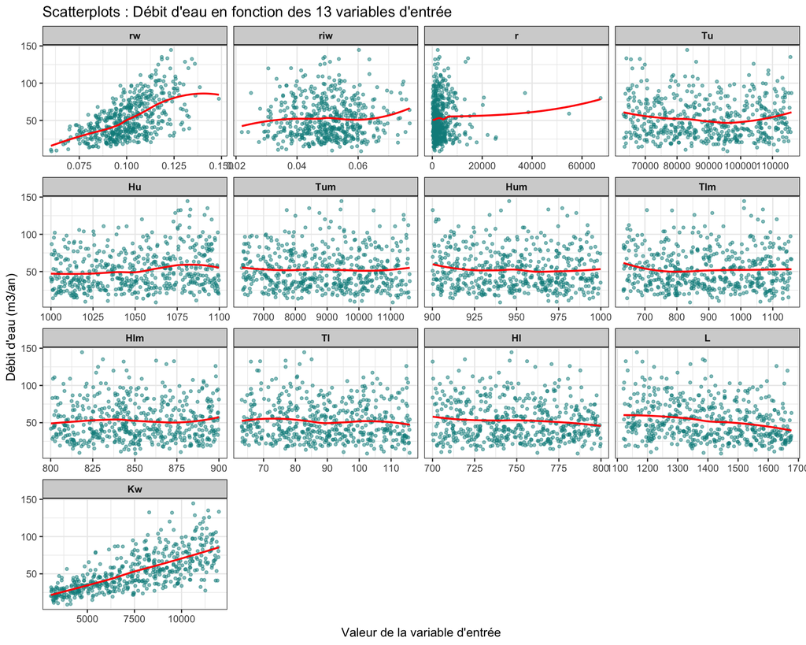

```r
library(tidyr)

# Génération de l'échantillon N = 500
set.seed(123)
N_500 <- 500
X_500 <- as.data.frame(EchantBorehole(N_500))
y_500 <- borehole(as.matrix(X_500))

# Préparation des données pour ggplo
df_500 <- X_500
df_500$Debit <- y_500
df_long <- pivot_longer(df_500, cols = -Debit, names_to = "Variable", values_to = "Valeur")

# Ordre des variables pour un affichage propre
df_long$Variable <- factor(df_long$Variable, levels = colnames(X_500))

# Création des scatterplots avec lissage (pour voir la tendance)
ggplot(df_long, aes(x = Valeur, y = Debit)) +
  geom_point(alpha = 0.5, color = "darkcyan", size = 1) +
  geom_smooth(method = "loess", color = "red", se = FALSE, linewidth = 0.8) +
  facet_wrap(~ Variable, scales = "free_x", ncol = 4) +
  labs(title = "Scatterplots : Débit d'eau en fonction des 13 variables d'entrée",
       x = "Valeur de la variable d'entrée",
       y = "Débit d'eau (m3/an)") +
  theme_bw() +
  theme(strip.background = element_rect(fill = "lightgrey", color = "black"),
        strip.text = element_text(face = "bold"))
```

**Interprétation visuelle des Scatterplots :**

L’analyse des nuages de points et de leurs courbes de tendance (en rouge) nous permet de tirer plusieurs conclusions préliminaires sur le comportement du modèle :

**Conclusion de l’analyse visuelle :** La forte non-linéarité observée (notamment sur `rw`) justifie le calcul du $R^2$ de la régression linéaire globale. Si ce dernier est faible, les indices SRC basés sur cette régression seront insuffisants, ce qui nous amènera naturellement à utiliser la méthode de décomposition de la variance (Indices de Sobol).

### 3-a) Suite : Indices basés sur la régression linéaire (SRC²)

Afin de quantifier numériquement l’influence des variables observée sur les scatterplots, nous calculons les indices de sensibilité **SRC** (Standardized Regression Coefficients) et **SRC²**. L’indice SRC² d’une variable représente la part de la variance de la sortie qui est expliquée par l’effet *linéaire* de cette variable.

Pour les estimer, nous utilisons la fonction `src()` du package `sensitivity`, couplée à un rééchantillonnage Bootstrap (`nboot = 100`) pour obtenir des intervalles de confiance. Nous calculons également le coefficient de détermination ($R^2$) du modèle linéaire global.

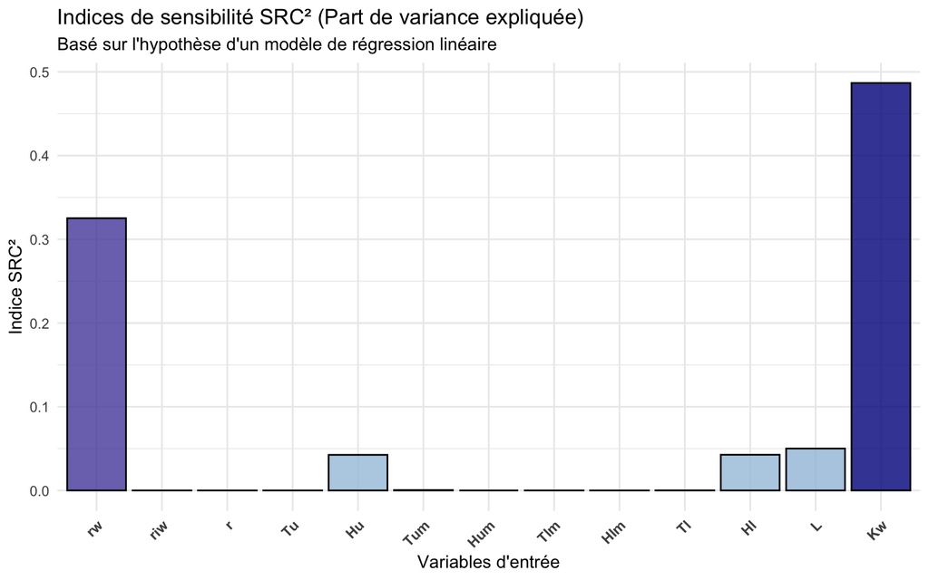

```r
# 1. Calcul des indices SRC avec bootstrap
set.seed(123)
indices_src <- src(X_500, y_500, nboot = 100)

# 2. Extraction des valeurs pour calculer le SRC²

df_src2 <- data.frame(
  Variable = factor(colnames(X_500), levels = colnames(X_500)),
  SRC2 = (indices_src$SRC$original)^2
)

# 3. Création d'un graphique avec ggplot2

ggplot(df_src2, aes(x = Variable, y = SRC2, fill = SRC2)) +
  geom_bar(stat = "identity", color = "black", alpha = 0.8) +
  scale_fill_gradient(low = "lightblue", high = "darkblue") +
  labs(title = "Indices de sensibilité SRC² (Part de variance expliquée)",
       subtitle = "Basé sur l'hypothèse d'un modèle de régression linéaire",
       x = "Variables d'entrée",
       y = "Indice SRC²") +
  theme_minimal() +
  theme(axis.text.x = element_text(angle = 45, hjust = 1, face = "bold"),
        legend.position = "none")
```

**Interprétation des indices de sensibilité** $SRC^2$ :

Le graphique en barres des indices $SRC^2$ nous permet de quantifier la part de variance de la sortie expliquée par chaque variable, sous l’hypothèse stricte d’un modèle linéaire.

*C’est pourquoi, comme suggéré par l’inégalité de Jensen à la question 2-b. cette analyse n’est pas suffisante car elle a une limite majeure : elle analyse seulement les relations du premier ordre et pas les effets des interactions entre les entrées. Nous devons passer au calcul des indices de Sobol’*

### 3-b) Calcul et interprétation des indices de Sobol’

Pour capturer l’ensemble des effets (linéaires, non-linéaires et les interactions), nous utilisons l’analyse de variance via les indices de Sobol’. En nous basant sur les méthodes abordées lors du TP4, nous choisissons l’estimateur de **Martinez** (`sobolmartinez()`). Cette fonction est particulièrement adaptée car elle est robuste et permet le calcul simultané des indices de premier ordre ($S_i$) et totaux ($S_{T_i}$), tout en contrôlant la précision de nos estimations grâce au rééchantillonnage Bootstrap (`nboot = 100`).

Nous choisissons une taille d’échantillon $N = 10000$ pour les deux matrices indépendantes $X_1$ et $X_2$, ce qui offre un excellent compromis entre la convergence des estimateurs et le temps de calcul.

```r
# 1. Génération des échantillons (N = 10000)
n_sobol <- 10000
set.seed(42)
X1 <- EchantBorehole(n_sobol)
X2 <- EchantBorehole(n_sobol)

# Wrapper pour s'assurer que la sortie est bien un vecteur numérique
wrap_borehole <- function(X) { as.numeric(borehole(as.matrix(X))) }

# 2. Calcul des indices de Sobol SANS bootstrap (nboot = 0)
sa_borehole <- sobolmartinez(model = wrap_borehole, X1 = X1, X2 = X2, nboot = 100)
```

[output not shown]

```r
print(sa_borehole)
```

```
##
## Call:
## sobolmartinez(model = wrap_borehole, X1 = X1, X2 = X2, nboot = 100)
##
## Model runs: 150000
##
## First order indices:
##        original         bias  std. error   min. c.i.  max. c.i.
## rw  0.344251821 0.0002584092 0.010003846  0.32593276 0.36476536
## riw 0.001057793 0.0012739803 0.010148060 -0.02010906 0.02271745
## r   0.001067203 0.0012751989 0.010151653 -0.02009324 0.02272797
## Tu  0.001057761 0.0012739788 0.010148062 -0.02010910 0.02271741
## Hu  0.040296522 0.0017556822 0.010715701  0.01786661 0.06306708
## Tum 0.001057793 0.0012739803 0.010148060 -0.02010906 0.02271745
## Hum 0.001057793 0.0012739803 0.010148060 -0.02010906 0.02271745
## Tlm 0.001057793 0.0012739803 0.010148060 -0.02010906 0.02271745
## Hlm 0.001057793 0.0012739803 0.010148060 -0.02010906 0.02271745
## Tl  0.001055844 0.0012779918 0.010148806 -0.02012370 0.02274436
## Hl  0.033723345 0.0016581699 0.009986044  0.01277348 0.05374298
## L   0.051122637 0.0019181314 0.010817553  0.02720103 0.07672992
## Kw  0.464503914 0.0007817658 0.007365757  0.45067517 0.47972265
##
## Total indices:
##         original          bias   std. error     min. c.i.    max. c.i.
## rw  3.871843e-01 -4.107271e-04 6.572496e-03  3.761903e-01 4.002692e-01
## riw 0.000000e+00  2.775558e-17 5.771046e-17 -2.220446e-16 0.000000e+00
## r   1.424874e-06 -6.507171e-09 5.152254e-08  1.330641e-06 1.538343e-06
## Tu  3.655964e-12 -1.421308e-14 1.364275e-13  3.399165e-12 3.951811e-12
## Hu  4.453422e-02  1.233398e-04 9.379643e-04  4.257162e-02 4.659151e-02
## Tum 0.000000e+00  2.775558e-17 5.771046e-17 -2.220446e-16 0.000000e+00
## Hum 0.000000e+00  2.775558e-17 5.771046e-17 -2.220446e-16 0.000000e+00
## Tlm 0.000000e+00  2.775558e-17 5.771046e-17 -2.220446e-16 0.000000e+00
## Hlm 0.000000e+00  2.775558e-17 5.771046e-17 -2.220446e-16 0.000000e+00
## Tl  3.741720e-06  2.052085e-08 1.420778e-07  3.379301e-06 3.982551e-06
## Hl  4.536688e-02  6.324666e-05 9.438506e-04  4.328267e-02 4.703908e-02
## L   6.837469e-02  4.632936e-05 1.512360e-03  6.527862e-02 7.156538e-02
## Kw  5.245304e-01  5.938613e-04 8.851220e-03  5.087864e-01 5.433388e-01
```

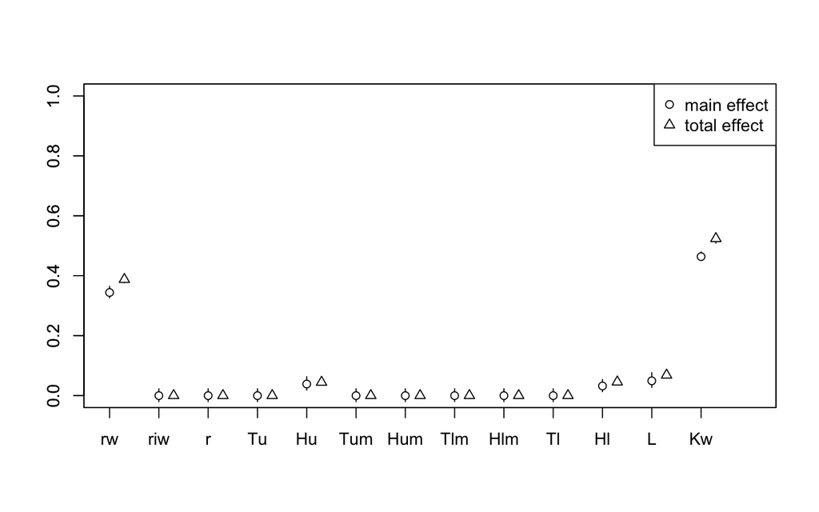

```r
# 3. Graphique natif propre
plot(sa_borehole, main = "Indices de Sobol' (1er Ordre et Totaux)")
```

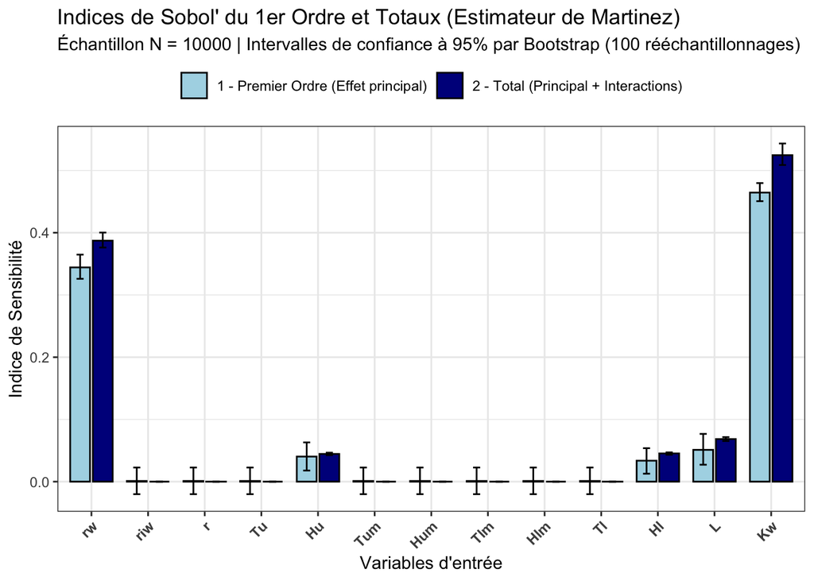

```r
df_sobol <- data.frame(
  Variable = factor(rownames(sa_borehole$S), levels = rownames(sa_borehole$S)),
  Premier_Ordre = sa_borehole$S$original,
  Premier_Ordre_min = sa_borehole$S$`min. c.i.`,
  Premier_Ordre_max = sa_borehole$S$`max. c.i.`,
  Total = sa_borehole$T$original,
  Total_min = sa_borehole$T$`min. c.i.`,
  Total_max = sa_borehole$T$`max. c.i.`
)

# Passage en format long pour faciliter la superposition sur ggplot
df_long_sobol <- data.frame(
  Variable = rep(df_sobol$Variable, 2),
  Type = rep(c("1 - Premier Ordre (Effet principal)", "2 - Total (Principal + Interactions)"), each = nrow(df_sobol)),
  Valeur = c(df_sobol$Premier_Ordre, df_sobol$Total),
  Min = c(df_sobol$Premier_Ordre_min, df_sobol$Total_min),
  Max = c(df_sobol$Premier_Ordre_max, df_sobol$Total_max)
)

# 4. Graphe des indices de Sobol avec intervalles de confiance
ggplot(df_long_sobol, aes(x = Variable, y = Valeur, fill = Type)) +
  geom_bar(stat = "identity", position = position_dodge(width = 0.8), color = "black", width = 0.7) +
  geom_errorbar(aes(ymin = Min, ymax = Max), position = position_dodge(width = 0.8), width = 0.25) +
  scale_fill_manual(values = c("lightblue", "darkblue")) +
  labs(title = "Indices de Sobol' du 1er Ordre et Totaux (Estimateur de Martinez)",
       subtitle = paste("Échantillon N =", n_sobol, "| Intervalles de confiance à 95% par Bootstrap (100 rééchantillonnages)"),
       x = "Variables d'entrée",
       y = "Indice de Sensibilité") +
  theme_bw() +
  theme(axis.text.x = element_text(angle = 45, hjust = 1, face = "bold"),
        legend.position = "top",
        legend.title = element_blank())
```

**Utilisation des outils d’interprétation quantitatifs :**

Afin d’aller plus loin que la simple observation visuelle, nous appliquons les outils de diagnostic standards de l’analyse de variance pour interpréter nos indices de Sobol’ :

```r
# Extraction des valeurs originales (estimations ponctuelles)
S_i <- sa_borehole$S$original
S_Ti <- sa_borehole$T$original
noms_var <- rownames(sa_borehole$S)

# Outil 1 : Degré d'additivité du modèle (Somme des indices de 1er ordre)
somme_S <- sum(S_i, na.rm = TRUE)
cat("La somme des indices de 1er ordre est de :", round(somme_S, 3), "\n")
```

```
## La somme des indices de 1er ordre est de : 0.942
```

```r
cat("Part de variance due aux interactions globales :", round((1 - somme_S)*100, 1), "%\n\n")
```

```
## Part de variance due aux interactions globales : 5.8 %
```

```r
# Outil 2 : Interactions pures par variable (S_Ti - S_i)
interactions <- S_Ti - S_i
df_outils <- data.frame(
  Variable = noms_var,
  S_i = round(S_i, 3),
  S_Ti = round(S_Ti, 3),
  Interaction_pure = round(interactions, 3)
)

# Tri par indice total décroissant pour hiérarchiser les paramètres
df_outils <- df_outils[order(-df_outils$S_Ti), ]

# Outil 3 : Screening (Seuil de significativité)
df_outils$Statut <- ifelse(df_outils$S_Ti < 0.01, "Négligeable", "Influente")

# Affichage du tableau de synthèse
knitr::kable(df_outils, row.names = FALSE,
             caption = "Diagnostic quantitatif des indices de Sobol'")
```

Diagnostic quantitatif des indices de Sobol’

| Variable | S_i | S_Ti | Interaction_pure | Statut |
| --- | --- | --- | --- | --- |
| Kw | 0.465 | 0.525 | 0.060 | Influente |
| rw | 0.344 | 0.387 | 0.043 | Influente |
| L | 0.051 | 0.068 | 0.017 | Influente |
| Hu | 0.040 | 0.045 | 0.004 | Influente |
| Hl | 0.034 | 0.045 | 0.012 | Influente |
| riw | 0.001 | 0.000 | -0.001 | Négligeable |
| r | 0.001 | 0.000 | -0.001 | Négligeable |
| Tu | 0.001 | 0.000 | -0.001 | Négligeable |
| Tum | 0.001 | 0.000 | -0.001 | Négligeable |
| Hum | 0.001 | 0.000 | -0.001 | Négligeable |
| Tlm | 0.001 | 0.000 | -0.001 | Négligeable |
| Hlm | 0.001 | 0.000 | -0.001 | Négligeable |
| Tl | 0.001 | 0.000 | -0.001 | Négligeable |

**Synthèse de l’interprétation quantitative :**

L’application des outils de diagnostic sur nos indices de Sobol’ nous permet de tirer les conclusions définitives suivantes :

1. **Degré d’additivité du modèle :** La somme des indices de premier ordre s’élève à **0.942**. Cela prouve quantitativement que le modèle `borehole` est majoritairement additif. Toutefois, environ **5.8 % de la variabilité totale** du débit d’eau est pilotée exclusivement par des interactions entre les paramètres (effets conjoints).
2. **Localisation des interactions :** La colonne des “Interactions pures” ($S_{T_i} - S_i$) confirme que c’est la variable `Kw` (conductivité hydraulique) qui interagit le plus avec les autres (0.060), suivie de près par `rw` (0.043) et `L` (0.017). Cela reflète la structure du dénominateur de l’équation mathématique du forage, où ces termes sont couplés multiplicativement dans le calcul de la résistance hydraulique.
3. **Screening et simplification du modèle :** En appliquant un seuil de coupure pragmatique de 1% ($S_{T_i} < 0.01$) sur les indices totaux, l’outil de *screening* nous permet de diviser nos 13 variables en deux groupes distincts :
   - **Variables influentes (5) :** `Kw`, `rw`, `L`, `Hu`, et `Hl` dirigent à elles seules plus de 99% de la variance du modèle.
   - **Variables négligeables (8) :** Les variables de l’aquifère moyen, ainsi que `riw`, `r`, `Tu` et `Tl` n’ont aucune influence significative. Le modèle de forage pourrait donc être mathématiquement réduit à 5 variables actives sans perte d’information majeure.

> **Note sur le bruit numérique :** L’apparition de très légères valeurs négatives pour les interactions pures de certaines variables inactives (ex: -0.001) est un artefact classique de la méthode d’estimation par Monte Carlo (bruit numérique des estimateurs). Cela confirme que leur vraie valeur théorique est 0.

# 4) Ajustement et utilisation d’un métamodèle de krigeage

### 4-a) Ajustement, validation ($Q^2$) et comparaison avec la régression linéaire

Pour pallier les limites du modèle de régression linéaire, nous ajustons un métamodèle basé sur les processus gaussiens (Krigeage) sur notre échantillon d’apprentissage de taille $N = 500$.

Nous utilisons le package `DiceKriging` vu en cours. Nous choisissons un noyau de covariance de type **Matérn 5/2** (`covtype="matern5_2"`), particulièrement adapté pour modéliser des fonctions physiques régulières. Pour valider ce métamodèle en dimension 13, nous utilisons la validation croisée *Leave-One-Out* (LOO), qui permet d’estimer le coefficient de prédictivité $Q^2$ sans avoir recours à un nouvel échantillon de test.

```r
library(DiceKriging)

# 1. Ajustement du modèle de Krigeage avec noyau Matern 5/2
set.seed(123)
krig <- km(formula = ~1, design = X_500, response = y_500,
           covtype = "matern5_2")
```

[output not shown]

[output cut: 63 more lines]

[output not shown]

```r
# 2. Validation croisée Leave-One-Out (LOO) pour estimer la précision
loo <- leaveOneOut.km(krig, type = "UK")

# 3. Calcul du coefficient de prédictivité Q²
residus_loo <- loo$mean - y_500
Q2 <- 1 - mean(residus_loo^2) / var(y_500)

# Rappel du R² de la régression linéaire (Question 3a)
r2_lm <- summary(lm(y_500 ~ ., data = as.data.frame(X_500)))$r.squared

cat("R² du modèle de régression linéaire :", round(r2_lm, 4), "\n")
```

```
## R² du modèle de régression linéaire : 0.9419
```

```r
cat("Q² du métamodèle de krigeage (LOO)  :", round(Q2, 4), "\n")
```

```
## Q² du métamodèle de krigeage (LOO)  : 0.9952
```

**3. Améliore-t-il le modèle de régression linéaire ? (Interprétation des résultats)**

**Oui, l’amélioration est significative et mathématiquement cohérente.** * **Le plafond du modèle linéaire :** La régression linéaire classique obtient un $R^2$ de **0.9419**. Fait remarquable : cette valeur correspond très exactement à la somme des indices de Sobol’ du 1er ordre (0.942) que nous avons calculée à la question précédente. Cela prouve que le modèle linéaire a parfaitement capté la part additive (les effets principaux) de la fonction `borehole`, mais qu’il est structurellement incapable d’aller plus loin. Il ignore les ~6% de variance liés aux interactions. * **La supériorité du Krigeage :** Le métamodèle de krigeage, en revanche, atteint un $Q^2$ de **0.9952** (soit une précision de 99.5% sur de nouvelles données). Grâce à sa structure spatiale (le processus gaussien), il agit comme une toile flexible qui s’ajuste aux courbures de la fonction en dimension 13. Il a implicitement “appris” les interactions entre les paramètres (notamment le couplage entre $K_w$, $r_w$ et $L$ au dénominateur).

**Conclusion :** Le krigeage améliore nettement la régression linéaire en comblant l’écart de variance manquante. Il remplace donc de manière extrêmement fiable le modèle physique tout en étant infiniment plus rapide à évaluer.

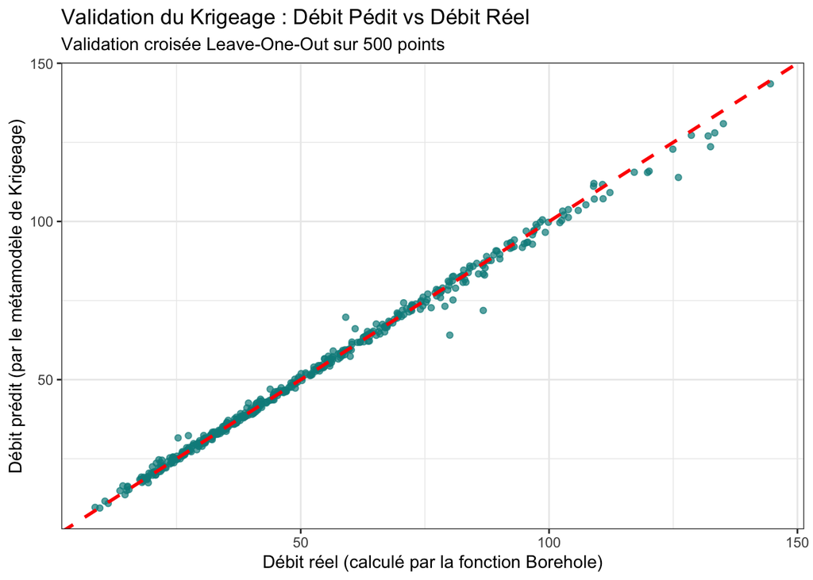

```r
# 3. Création du graphique Prédit vs Réel
df_krig <- data.frame(Reel = y_500, Predit = loo$mean)

ggplot(df_krig, aes(x = Reel, y = Predit)) +
  geom_point(color = "darkcyan", alpha = 0.7) +
  geom_abline(intercept = 0, slope = 1, color = "red", linetype = "dashed", linewidth = 1) +
  labs(title = "Validation du Krigeage : Débit Pédit vs Débit Réel",
       subtitle = "Validation croisée Leave-One-Out sur 500 points",
       x = "Débit réel (calculé par la fonction Borehole)",
       y = "Débit prédit (par le métamodèle de Krigeage)") +
  theme_bw()
```

### 4-b) Calcul des indices de Sobol’ à l’aide du métamodèle

Puisque notre métamodèle de krigeage a un $Q^2$ exceptionnel (0.9952), nous pouvons l’utiliser pour remplacer le modèle physique lourd lors du calcul des indices de Sobol’. L’avantage est que le krigeage est beaucoup plus rapide à évaluer sur des dizaines de milliers de points.

Nous utilisons la méthodologie vue en cours : création d’un plan d’expérience vide avec `sobolmartinez(model = NULL)`, prédiction des réponses via le métamodèle avec `predict.km()`, et intégration des résultats avec la fonction `tell()`. Nous reprenons la même taille d’échantillon ($N = 10000$) qu’à la question 3 pour comparer équitablement les résultats.

```r
library(sensitivity)
library(DiceKriging)

# 1. Génération des échantillons d'entrée
n_sobol_krig <- 10000
set.seed(123)
X1_krig <- EchantBorehole(n_sobol_krig)
X2_krig <- EchantBorehole(n_sobol_krig)

# 2. Initialisation de l'objet Sobol (modèle = NULL)
sa_krig <- sobolmartinez(model = NULL, X1 = X1_krig, X2 = X2_krig, nboot = 100)

# 3. Prédiction des réponses sur le plan d'expérience (150 000 points) par le Krigeage
# Le krigeage calcule instantanément les prédictions
pred_krig <- predict.km(krig, newdata = sa_krig$X, type = "UK", checkNames = FALSE, se.compute = FALSE)

tell(sa_krig, pred_krig$mean)

# 5. Affichage des résultats
knitr::kable(sa_krig$S, digits = 4, caption = "Indices de 1er Ordre (via Krigeage)")
```

Indices de 1er Ordre (via Krigeage)

|  | original | bias | std. error | min. c.i. | max. c.i. |
| --- | --- | --- | --- | --- | --- |
| rw | 0.3489 | 1e-04 | 0.0091 | 0.3320 | 0.3693 |
| riw | 0.0096 | 5e-04 | 0.0105 | -0.0119 | 0.0280 |
| r | 0.0098 | 5e-04 | 0.0105 | -0.0120 | 0.0283 |
| Tu | 0.0096 | 6e-04 | 0.0106 | -0.0120 | 0.0280 |
| Hu | 0.0420 | 8e-04 | 0.0105 | 0.0203 | 0.0609 |
| Tum | 0.0095 | 5e-04 | 0.0105 | -0.0117 | 0.0280 |
| Hum | 0.0098 | 5e-04 | 0.0106 | -0.0116 | 0.0282 |
| Tlm | 0.0091 | 6e-04 | 0.0106 | -0.0125 | 0.0276 |
| Hlm | 0.0098 | 5e-04 | 0.0106 | -0.0116 | 0.0285 |
| Tl | 0.0098 | 5e-04 | 0.0106 | -0.0117 | 0.0285 |
| Hl | 0.0403 | 1e-03 | 0.0112 | 0.0158 | 0.0602 |
| L | 0.0605 | 6e-04 | 0.0110 | 0.0355 | 0.0795 |
| Kw | 0.4823 | -6e-04 | 0.0069 | 0.4715 | 0.4993 |

```r
knitr::kable(sa_krig$T, digits = 4, caption = "Indices Totaux (via Krigeage)")
```

Indices Totaux (via Krigeage)

|  | original | bias | std. error | min. c.i. | max. c.i. |
| --- | --- | --- | --- | --- | --- |
| rw | 0.3783 | -8e-04 | 0.0069 | 0.3657 | 0.3932 |
| riw | 0.0001 | 0e+00 | 0.0000 | 0.0001 | 0.0001 |
| r | 0.0023 | 0e+00 | 0.0003 | 0.0016 | 0.0029 |
| Tu | 0.0002 | 0e+00 | 0.0000 | 0.0002 | 0.0002 |
| Hu | 0.0423 | -1e-04 | 0.0008 | 0.0409 | 0.0439 |
| Tum | 0.0005 | 0e+00 | 0.0000 | 0.0004 | 0.0005 |
| Hum | 0.0002 | 0e+00 | 0.0000 | 0.0002 | 0.0002 |
| Tlm | 0.0005 | 0e+00 | 0.0000 | 0.0005 | 0.0006 |
| Hlm | 0.0002 | 0e+00 | 0.0000 | 0.0002 | 0.0003 |
| Tl | 0.0002 | 0e+00 | 0.0000 | 0.0002 | 0.0002 |
| Hl | 0.0424 | 0e+00 | 0.0009 | 0.0404 | 0.0439 |
| L | 0.0627 | 1e-04 | 0.0013 | 0.0601 | 0.0655 |
| Kw | 0.5231 | -9e-04 | 0.0085 | 0.5052 | 0.5400 |

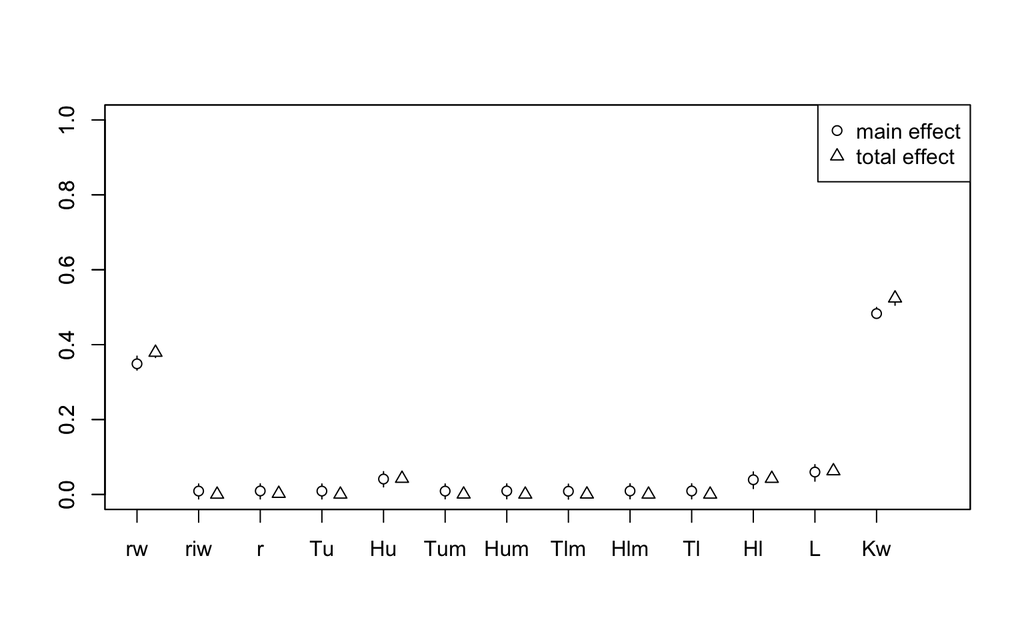

```r
# 6. Graphique des indices
plot(sa_krig, main = "Indices de Sobol' estimés sur le métamodèle de Krigeage")
```